# MIT VAR Example

From https://ocw.mit.edu/courses/mathematics/18-s096-topics-in-mathematics-with-applications-in-finance-fall-2013/case-studies/MIT18_S096F13_CaseStudy5.pdf

### Load data

```r
getSymbols(c("UNRATE", "FEDFUNDS", "TB3MS", "CPIAUCSL", "M1SL", "GDPDEF", "GDP", "GPDI", "TWEXBMTH"), src="FRED")
```

```
[1] "UNRATE"   "FEDFUNDS" "TB3MS"    "CPIAUCSL" "M1SL"     "GDPDEF"   "GDP"      "GPDI"     "TWEXBMTH"
```

```r
SP500 <- getSymbols("^GSPC", src="yahoo", auto.assign=F)
```

### 1.3 Ordinary and Partial Autocorrelations of Reduced Set

```r
# Consider focusing on 3 variables
ymat0<-merge(UNRATE, FEDFUNDS, CPIAUCSL)
ind.quarterly0<-1*(is.na(ymat0[,3])==FALSE)
sum(ind.quarterly0)
```

```
[1] 879
```

```r
dim(ymat0)
```

```
[1] 879   3
```

```r
ymat00<-ymat0[which(ind.quarterly0==1),]
head(ymat00)
```

```
           UNRATE FEDFUNDS CPIAUCSL
1947-01-01     NA       NA    21.48
1947-02-01     NA       NA    21.62
1947-03-01     NA       NA    22.00
1947-04-01     NA       NA    22.00
1947-05-01     NA       NA    21.95
1947-06-01     NA       NA    22.08
```

```r
par(mfcol=c(3,1))
plot(ymat00[,1],main=dimnames(ymat00)[[2]][1])
plot(ymat00[,2],main=dimnames(ymat00)[[2]][2])
```

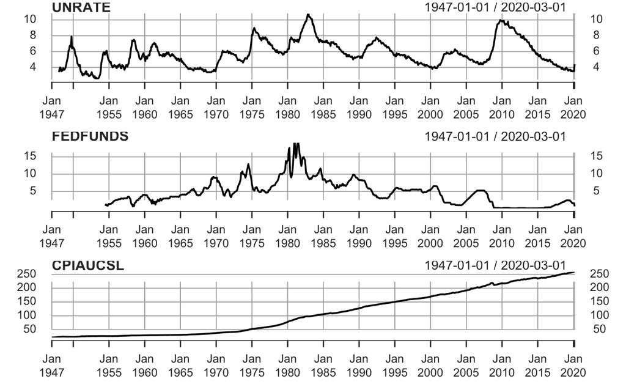

```r
plot(ymat00[,3],main=dimnames(ymat00)[[2]][3])
```

```r
 ymat00.0<-window(ymat00
                  , start = as.Date("1960-01-01")
                  , end = as.Date("2000-12-31"))
dim(ymat00.0)
```

```
[1] 492   3
```

```r
head(ymat00.0)
```

```
           UNRATE FEDFUNDS CPIAUCSL
1960-01-01    5.2     3.99    29.37
1960-02-01    4.8     3.97    29.41
1960-03-01    5.4     3.84    29.41
1960-04-01    5.2     3.92    29.54
1960-05-01    5.1     3.85    29.57
1960-06-01    5.4     3.32    29.61
```

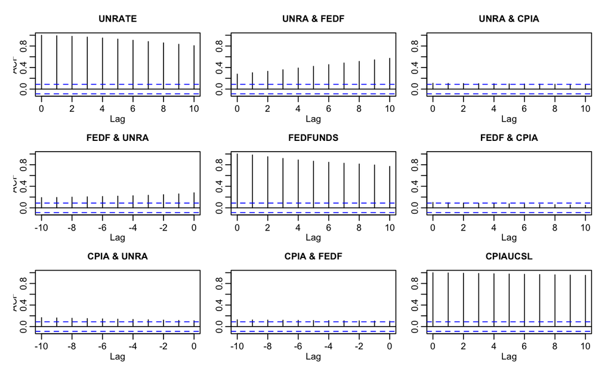

```r
acf(ymat00.0, lag.max=10)
```

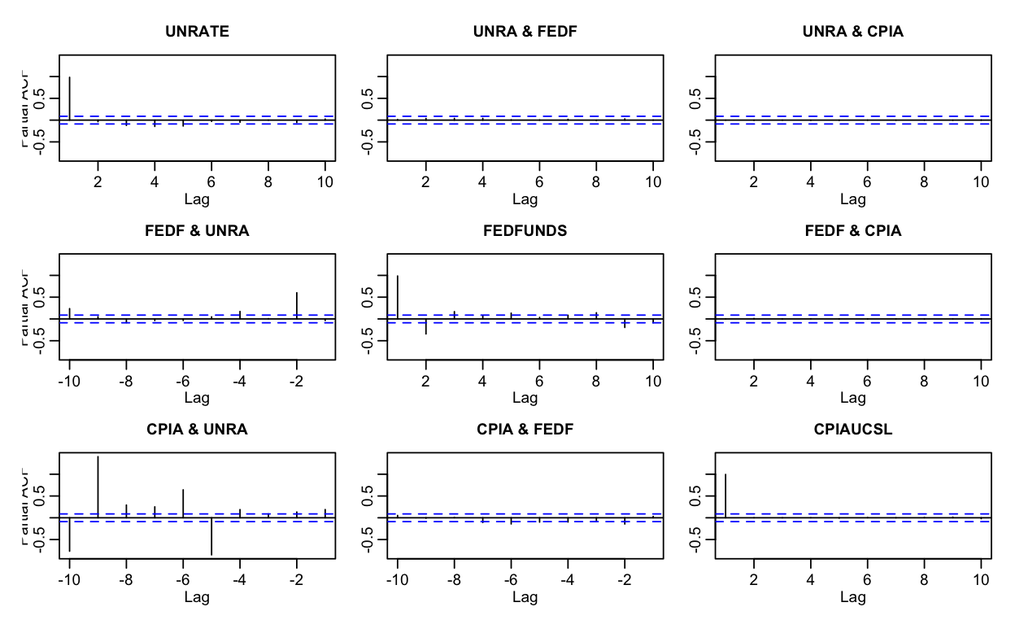

```r
acf(ymat00.0, type="partial", lag.max=10)
```

### 1.4 Vector Autoregressive (VAR) Model of Reduced Set

```r
 # The function VARselect() is from the package vars; see Pfaff(2008).
# This function identifies the optimal VAR(p) order p.
ymat00.0.VAR.const<-VARselect(ymat00.0, lag.max=12, type="const")
# Print out the VAR order identified by different information criteria
ymat00.0.VAR.const$selection
```

```
AIC(n)  HQ(n)  SC(n) FPE(n)
    12      5      2     12
```

```r
# Fit the VAR model corresponding to the Schwarz Criterion (SC) which is the BIC
ymat00.0.VAR.const.0<-VAR(ymat00.0, p=ymat00.0.VAR.const$selection[3],type="const")
options(show.signif.stars=FALSE)
summary(ymat00.0.VAR.const.0)
```

```
VAR Estimation Results:
=========================
Endogenous variables: UNRATE, FEDFUNDS, CPIAUCSL
Deterministic variables: const
Sample size: 490
Log Likelihood: -90.684
Roots of the characteristic polynomial:
1.002 0.9863 0.9524 0.4675 0.3314 0.08405
Call:
VAR(y = ymat00.0, p = ymat00.0.VAR.const$selection[3], type = "const")


Estimation results for equation UNRATE:
=======================================
UNRATE = UNRATE.l1 + FEDFUNDS.l1 + CPIAUCSL.l1 + UNRATE.l2 + FEDFUNDS.l2 + CPIAUCSL.l2 + const

            Estimate Std. Error t value Pr(>|t|)
UNRATE.l1    0.97239    0.04593  21.171  < 2e-16
FEDFUNDS.l1 -0.02928    0.01363  -2.148  0.03222
CPIAUCSL.l1  0.01744    0.04114   0.424  0.67176
UNRATE.l2    0.01157    0.04557   0.254  0.79974
FEDFUNDS.l2  0.04348    0.01373   3.168  0.00163
CPIAUCSL.l2 -0.01777    0.04121  -0.431  0.66642
const        0.02390    0.03558   0.672  0.50212


Residual standard error: 0.177 on 483 degrees of freedom
Multiple R-Squared: 0.9865, Adjusted R-squared: 0.9864
F-statistic:  5891 on 6 and 483 DF,  p-value: < 2.2e-16


Estimation results for equation FEDFUNDS:
=========================================
FEDFUNDS = UNRATE.l1 + FEDFUNDS.l1 + CPIAUCSL.l1 + UNRATE.l2 + FEDFUNDS.l2 + CPIAUCSL.l2 + const

            Estimate Std. Error t value Pr(>|t|)
UNRATE.l1   -0.65364    0.14326  -4.563 6.42e-06
FEDFUNDS.l1  1.31042    0.04252  30.816  < 2e-16
CPIAUCSL.l1  0.20253    0.12832   1.578   0.1152
UNRATE.l2    0.64608    0.14213   4.546 6.93e-06
```

[output cut: 26 more lines]

```
F-statistic: 5.755e+06 on 6 and 483 DF,  p-value: < 2.2e-16



Covariance matrix of residuals:
            UNRATE  FEDFUNDS  CPIAUCSL
UNRATE    0.031327 -0.018662 -0.001303
FEDFUNDS -0.018662  0.304767  0.008291
CPIAUCSL -0.001303  0.008291  0.033232

Correlation matrix of residuals:
           UNRATE FEDFUNDS CPIAUCSL
UNRATE    1.00000 -0.19099 -0.04038
FEDFUNDS -0.19099  1.00000  0.08239
CPIAUCSL -0.04038  0.08239  1.00000
```

### 1.5 Impulse Response Functions for a Fitted VAR(p) Model

The impulse response function measure the impact of a unit innovation (impulse) in a given variable on all the dependent variables in the VAR model.

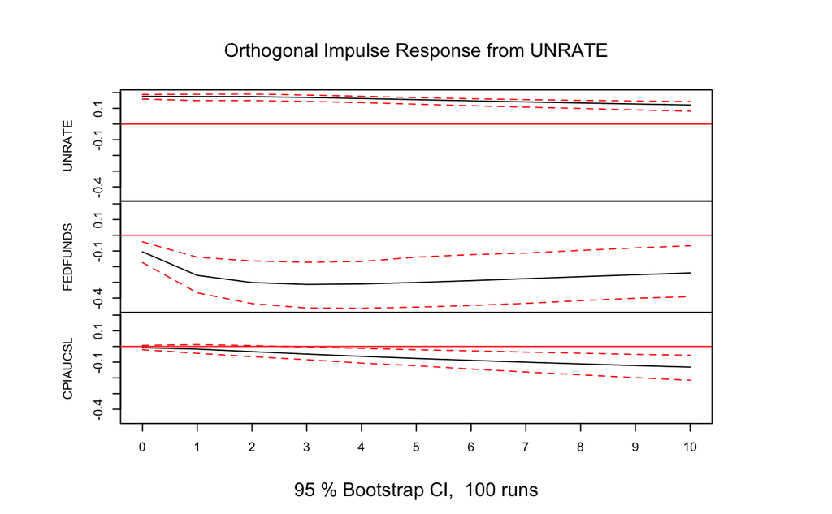

```r
plot(irf(ymat00.0.VAR.const.0, impulse="UNRATE"))
```

```r
# When unemployment rises:
# the Federal Funds rate is projected to decline
# (consistent with Federal Reserve Policy)
#
# the CPI decreases (lower employment results in less
# pressure to increase consumer prices)
```

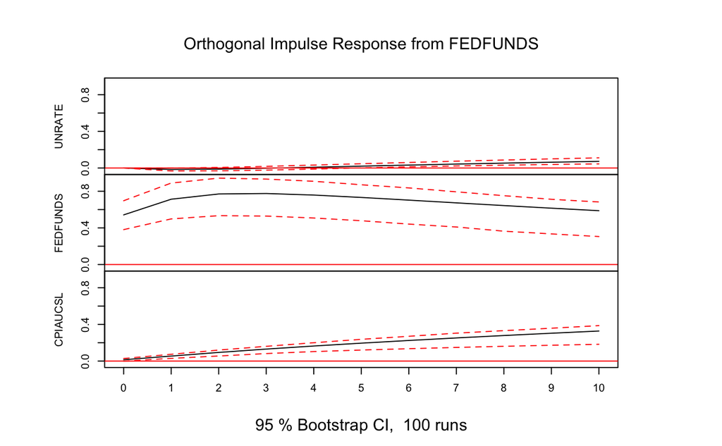

```r
plot(irf(ymat00.0.VAR.const.0, impulse="FEDFUNDS"))
```

```r
# When the Fed Funds rate increases:
#
# The Unemployment rate tends to increase;
# so reducing the Fed Funds rate would tend to reduce unemployment
#
# The CPI increases; increases in the Fed Funds rate are
# associated with increase in CPI over future quarters
```

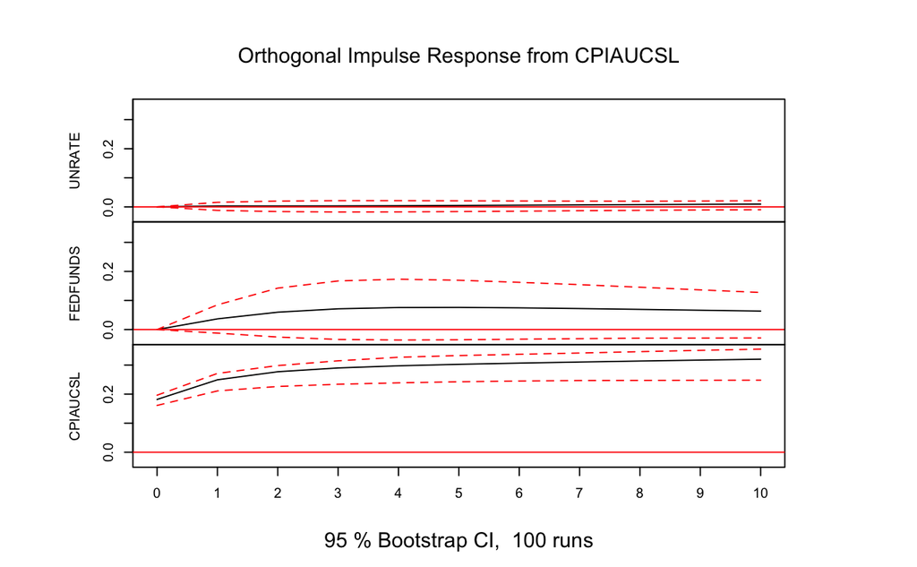

```r
plot(irf(ymat00.0.VAR.const.0, impulse="CPIAUCSL"))
```

When the CPI increases

The Federal Funds rate tends to increase over subsequent quarters. This is consistent with Federal Reserve policy of raising interest rates to control for inflation.

### 1.6 Ordinary and Partial Autocorrelations of Differenced Series

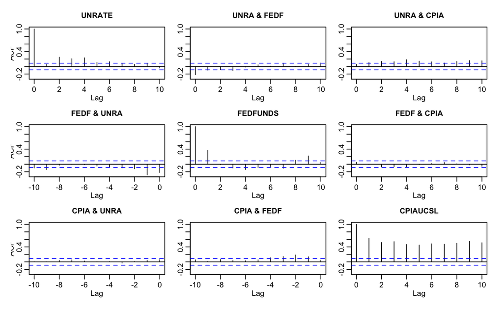

```r
ymat000.0<-na.omit(diff(ymat00.0))
acf(ymat000.0, lag.max=10)
```

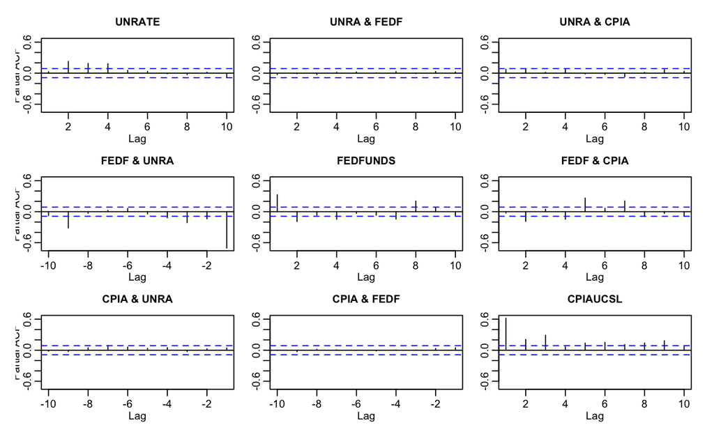

```r
acf(ymat000.0, type="partial", lag.max=10)
```

### 1.7 Vector Autoregressive (VAR) Model with Differenced Series

```r
# The function VARselect() is from the package vars; see Pfaff(2008).
# This function identifies the optimal VAR(p) order p.
ymat000.0.VAR.const<-VARselect(ymat000.0, lag.max=12, type="const")
# Print out the VAR order identified by different information criteria
ymat000.0.VAR.const$selection
```

```
AIC(n)  HQ(n)  SC(n) FPE(n)
    12      3      3     12
```

```r
# Fit the VAR model corresponding to the Schwarz Criterion (SC) which is the BIC
ymat000.0.VAR.const.0<-VAR(ymat000.0, p=ymat000.0.VAR.const$selection[3],type="const")
options(show.signif.stars=FALSE)
summary(ymat000.0.VAR.const.0)
```

```
VAR Estimation Results:
=========================
Endogenous variables: UNRATE, FEDFUNDS, CPIAUCSL
Deterministic variables: const
Sample size: 488
Log Likelihood: -69.438
Roots of the characteristic polynomial:
0.8369 0.7659 0.584 0.584 0.5755 0.5755 0.4907 0.4907 0.3088
Call:
VAR(y = ymat000.0, p = ymat000.0.VAR.const$selection[3], type = "const")


Estimation results for equation UNRATE:
=======================================
UNRATE = UNRATE.l1 + FEDFUNDS.l1 + CPIAUCSL.l1 + UNRATE.l2 + FEDFUNDS.l2 + CPIAUCSL.l2 + UNRATE.l3 + FEDFUNDS.l3 + CPIAUCSL.l3 + const

             Estimate Std. Error t value Pr(>|t|)
UNRATE.l1   -0.007647   0.045642  -0.168   0.8670
FEDFUNDS.l1 -0.010946   0.014641  -0.748   0.4551
CPIAUCSL.l1  0.033734   0.040703   0.829   0.4076
UNRATE.l2    0.220669   0.044850   4.920 1.19e-06
FEDFUNDS.l2  0.016837   0.015397   1.094   0.2747
CPIAUCSL.l2  0.060812   0.044099   1.379   0.1685
UNRATE.l3    0.182936   0.045599   4.012 6.99e-05
FEDFUNDS.l3 -0.027506   0.014294  -1.924   0.0549
CPIAUCSL.l3  0.015690   0.040408   0.388   0.6980
const       -0.034330   0.013372  -2.567   0.0106


Residual standard error: 0.1714 on 478 degrees of freedom
Multiple R-Squared: 0.1238, Adjusted R-squared: 0.1073
F-statistic: 7.507 on 9 and 478 DF,  p-value: 2.636e-10


Estimation results for equation FEDFUNDS:
=========================================
FEDFUNDS = UNRATE.l1 + FEDFUNDS.l1 + CPIAUCSL.l1 + UNRATE.l2 + FEDFUNDS.l2 + CPIAUCSL.l2 + UNRATE.l3 + FEDFUNDS.l3 + CPIAUCSL.l3 + const

             Estimate Std. Error t value Pr(>|t|)
UNRATE.l1   -0.712680   0.145160  -4.910 1.25e-06
```

[output cut: 35 more lines]

```
F-statistic: 50.11 on 9 and 478 DF,  p-value: < 2.2e-16



Covariance matrix of residuals:
             UNRATE  FEDFUNDS   CPIAUCSL
UNRATE    0.0293761 -0.019046 -0.0005205
FEDFUNDS -0.0190462  0.297133  0.0057060
CPIAUCSL -0.0005205  0.005706  0.0340444

Correlation matrix of residuals:
           UNRATE FEDFUNDS CPIAUCSL
UNRATE    1.00000 -0.20386 -0.01646
FEDFUNDS -0.20386  1.00000  0.05673
CPIAUCSL -0.01646  0.05673  1.00000
```

### 1.8 Impulse Response Functions for VAR(p) Fit of Differenced Series

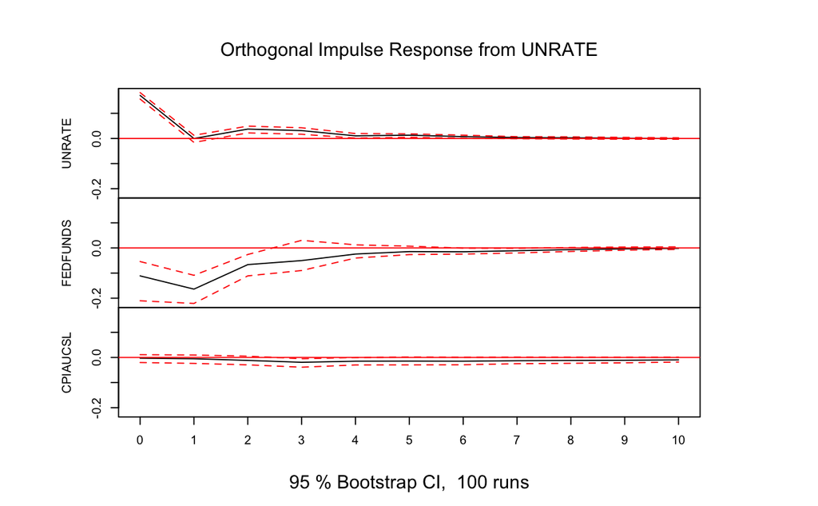

```r
plot(irf(ymat000.0.VAR.const.0, impulse="UNRATE"))
```

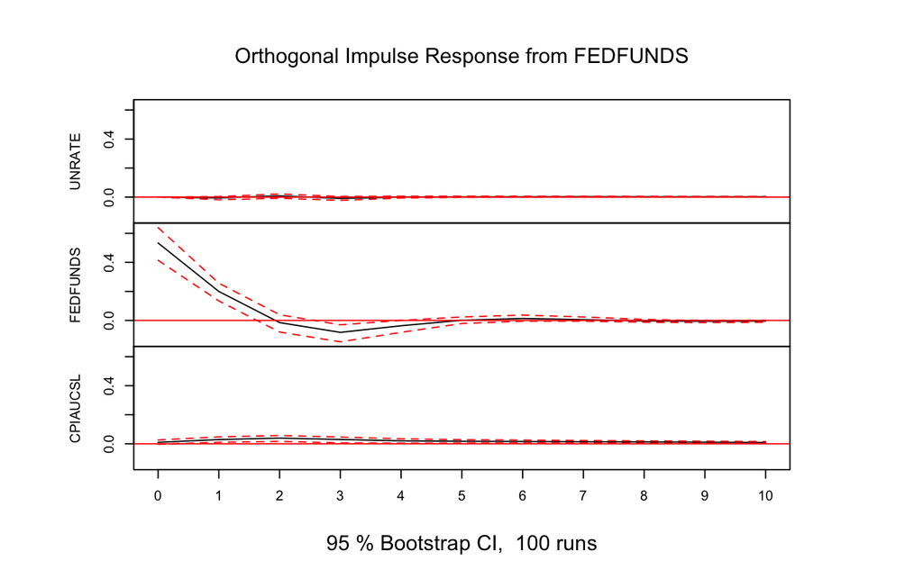

```r
plot(irf(ymat000.0.VAR.const.0, impulse="FEDFUNDS"))
```

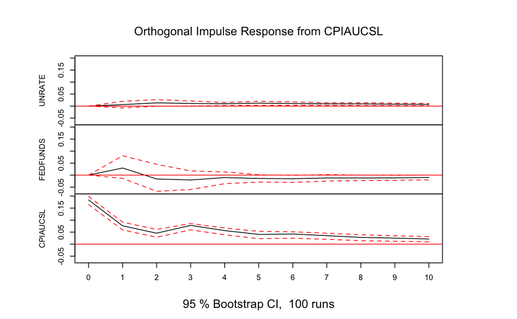

```r
plot(irf(ymat000.0.VAR.const.0, impulse="CPIAUCSL"))
```

Interpreting the impulse response functions for the VAR model of the differenced series, we note: • When unemployment increases, the Fed Funds rate tends to decrease over subsequent quarters, consistent with Federal Reserve policies (i.e., stimulating economic growth and employment with lower interest rates). • When the Fed Funds rate increases, there is a modest increase in inflation (CPIA). This is consistent with the Fed raising rates to control inflation which tends to persist for several quarters (note the high 3-rd quarter lag partial autocorrelation in CPIAUCSL). • When inflation (CPIAUCSL) increases, unemployment tends to rise modestly, and the Fed Funds rate tends to increase.

References Bernard Pfaff (2008). VAR, SVAR and SVEC Models: Implementation With R Package vars, Journal of Statistical Software 27(4). URL http://www.jstatsoft.org/v27/i04/. Robert Litterman (1979). Techniques of Forecasting Using Vector Autoregressions. Working Paper # 115, Federal Reserve Bank of Minneapolis. Christopher Sims (1989). A Nine Variable Probabilistic Macroeconomic Forecasting Model. Discussion Paper 14, Federal Reserve Bank of Minneapolis.